# Economy of music in Europe: Novel data collection methods and indicators

DOI: 10.5281/zenodo.6464990

Daniel Antal, CFA, Reprex & University of Amsterdam

Poort, Joost, PhD, University of Amsterdam

Botazzi, Guilio, PhD, University of Pisa

Andrés García Molina, PhD, Reprex

2023-05-14

## Abstract

In the last decade, the evidence-based policy movement gained significant traction in Europe as well as globally. Its focus has been to increase the rigour of the evidence generated, to improve the credibility and understandability of evidence created for policy purposes. As evidence-based policies often rely on scientific evidence, the evidence-based policy movement went hand in hand with the efforts to increase the transparency and reproducibility of scientific research (See: (Munafò et al. 2017) and in an EU context (J 2015; Commission et al. 2020; European Commission and Directorate-General for Research and Innovation 2020).)

Our [Report on the European Music Economy](https://zenodo.org/record/6464782#.Ylq7JNpBzIU), and its supporting document, [Economy of music in Europe: Novel data collection methods and indicators](https://doi.org/10.5281/zenodo.6464990) will follow the Open Policy Analysis Guidelines and the best practices of the European Union’s Knowledge For Policy and the [European Open Science Cloud](https://eosc-portal.eu/) portal.

The aim of this document is to *share an open report that includes clear accounts of all methodological procedures, data, and assumptions.* Best practice: All project components are organized in a selfcontained folder using a Standard File Structure (SFS), and a readme file is included (in this case, [here](https://github.com/dataobservatory-eu/report-european-music-economy)). We place all files with SFS on the European open science repository Zenodo on zenodo.org/communities/music_observatory/.

## Data gaps

The *Feasibility study for the establishment of a European Music Observatory* (in short: EMO Feasibility Study)[^1] has identified 13 data gaps, and 4 existing but publicly not available data sources.

2. Filling the Data Gaps
1. Employment; 2. Value of EU’s music sector; 3. Structure of the market; 4. The impact of the not-forprofit sector on the overall economy of the music sector; 5. Neighbouring rights; 6. Music publishing; 7. Independent music companies; 8. Live music; 9. Export; 10. Music retail or in-store public performance; 11. Financing of the music sector; 12. Live music regulation; 13. Copyright regulations and evolution of copyright regimes.

Furthermore, the *EMO Feasiblity Study* mentions existing data sources that are collected by various organizations, such as GESAC, CISAC and IFPI.

The goals of the Diversity and Circulation Pillar greatly overlap with some aspects of the Economy of Music Pillar.

Cultural diversity policy goals, which want to ensure that the music scene of a country, region or city gets proper exposure on the local media and stages, or less popular genres still find a way to their audiences, go hand in hand with some competition policy and consumer protection targets, and they also align well with the objectives of intellectual property and copyright policies. Because almost all income of artists is connected to the use of music, a lack of diversity, and less opportunities for small-language repertoires, classical or jazz music, also lead to inadequate income connected to their composers, performers and a devaluation of their copyrights and neighboring rights. An excessive concentration of volume of use, and therefore revenues/market share for certain nations, or large publishers/labels is conflicting with competition policy goals.

The 8 years of research and policy use history of the Digital Music Observatory (formerly CEEMID) is connected both to competition law-based cases and cultural policy use cases, using the same data, and an overlapping methodology.

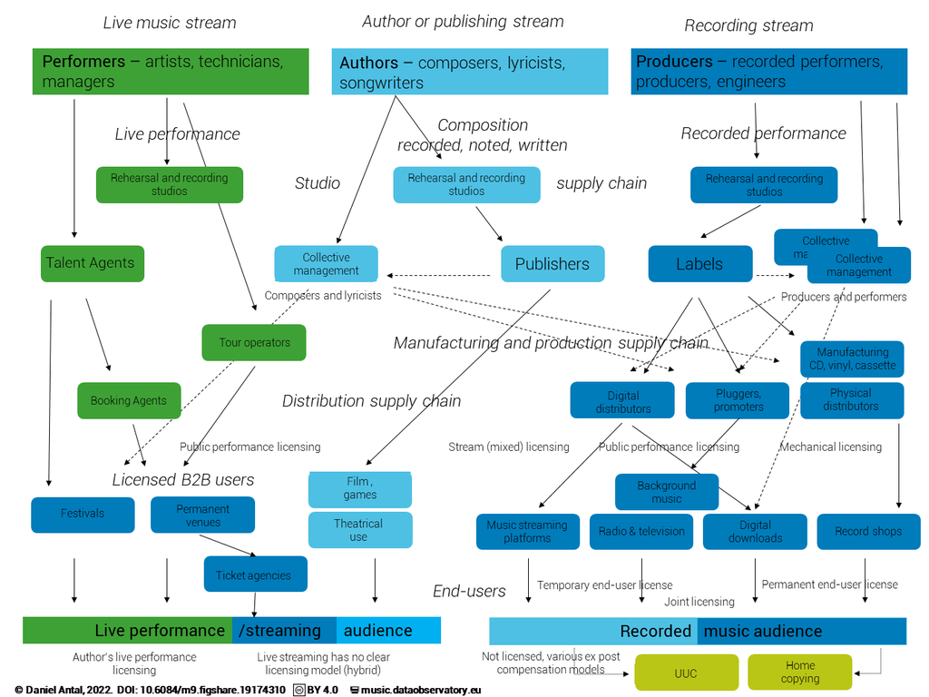

In the 21st century, about 60% of the recorded music sales are made by streaming and user-uploaded content platforms where it is mainly not human curators but AI algorithms that match the vast supply of content to users. These AI algorithms use machine learning from the available biographical, musicological, natural language processed lyrics and review information, the artists music history and the user interaction history, user demographics, and other complex, interrelated information. Our experience shows that a strong presence on global streaming and UUG platform requires a very sophisticated data infrastructure and data knowledge that is not present in smaller, independent music businesses, and not even in small-country national organizations.

The data of the Digital Music Observatory is used – outside the scope of this proposal – in trustworthy AI research when we try to assign blame for the less-than-optimal outcome for small business and small country repertoires for copyright data and metadata problems. These problems related to a larger problem that we work in both the *Economy of Music Pillar*[^2] and the the *Diversity and Circulation Pillar*[^3]. Indirectly, because copyright data management/metadata management problems are among the causes of *Music export*, *Structure of the market*, *Value of EU’s music sector*, *Employment*, *Independent music*, *Neighbouring rights* problems and data gaps of the *Economy of Music Pillar*, not only that of the Diversity & Circulation problems. Indirectly, because researching these problems requires the same data sources, the same data processing about music present in broadcast, retransmission, streaming and other non-mechanical channels of distribution.

In other words, the *Economy of Music Pillar* relies on very similar data like the *Diversity and Circulation Pillar*, but it uses the data in different analytical models. As a joint research project of IViR, Reprex, and other partners found, “… *costs* can also be understood in a broader sense. Instead of confining the analysis to monetary aspects, it is important to consider broader cultural repercussions, in particular the impact of standardised data formats and comprehensive copyright data systems on cultural diversity, recognition and attribution (in the sense of the moral rights enjoying protection under international copyright law and the national copyright systems of EU Member States) and the visibility and availability of the full spectrum of European creative works.”[^4].

Last, but not least, the [Towards a competitive, fair and sustainable European music ecosystem](https://ec.europa.eu/info/funding-tenders/opportunities/portal/screen/opportunities/topic-details/horizon-cl2-2022-heritage-01-05)[^5] grant call stresses out that “proposals should further research on the economy of the streaming models”. While the _EMO *Feasibility Study* places the topic of in the *Music Innovation Pillar*[^6], we deal with this problem in our WP Music Economy and WP Diversity & Circulation

Please find the authoritative copy of this document (or later versions) on [Zenodo](https://zenodo.org/record/6435322#.YlMVfMhBzIU). Subjects: [Music industry](https://id.loc.gov/authorities/subjects/sh85088944.html); [Valuation](https://id.loc.gov/authorities/subjects/sh85141927.html); [Copyright](https://id.loc.gov/authorities/subjects/sh85032446.html).

## Proposed Work in the Economics of Music Pillar of the Digital Music Observatory

## Task list

The task list was part of our Proposal to the [Towards a competitive, fair and sustainable European music ecosystem](https://ec.europa.eu/info/funding-tenders/opportunities/portal/screen/opportunities/topic-details/horizon-cl2-2022-heritage-01-05)[^7] grant call, and with very little modifications became part of our Grant Agreement (OpenMuse 2023).

The *Digital Music Observatory* has experience with collecting and internationally harmonizing data in 12/13 identified data gaps, with the exceptions of *The impact of the not-for-profit sector on the overall economy of the music sector*, and already has even pan-European and shared data in some areas, and maps the metadata of 4/4 identified existing, not available data sources. We will create and release some datatables and indicators for almost all data gaps, but our focus will be different from the *EMO Feasibility Study*, because the grant call itself has different priorities.

### T1.1 Music economy methodology and indicators

We will translate the data gaps identified by the *Feasibility study for the establishment of a European Music Observatory*. According the *Feasibility study for the establishment of a European Music Observatory* “CEEMID [currently the Digital Music Observatory] can transfer thousands of indicators that are reproducible and verifiable, open-source software that creates them to a European Music Observatory. In particular, CEEMID provides a useful and interesting approach to harnessing the possibilities of open data in Europe in relation to the music sector, which should be further explored by the European Music Observatory in its start-up phase.”[^8] Obviously, these transferable indicators are “indicator candidates”, because they have to be proven to be useful for representative music organizations, European or national policymakers. We will use this huge data trove created over 8 years and covering more than 30 European countries as a starting point. We will implement he Eurostat indicator design methodology with these “indicator candidates” for music stakeholders, according to the mapping of the music stakeholders to provide them with appropriate, understandable statistical information. While we will create indicator candidates, and final indicators in some cases for all EU member states, we will particularly focus on calculating indicator values in the Slovak Republic, where we will feed them into the policymaking channels of the Slovak Ministry of Culture and the Culture Committe of the Slovak National Assembly. (EUBA, IViR, Reprex)

### T1.1.1 Methodology of indicator design

- ST1 Data gap analysis and preliminary indicator candidate design.
- ST2 We will invite all representative European music stakeholders, and Slovak policy stakeholders to a workshop in Bratislava, where we will present many indicator candidates, show alternatives, and educate business and policy users about data availability and different use cases of various indicator candidates. EUBA, SOZA, IViR, Reprex
- ST3 We translate indicator needs into data collection tasks to be carried out in T1.2, T2.2, T3.2, and T4.1. EUBA, SOZA, IViR, Reprex

### T1.1.2 MSME survey design

Because freelancer and microneterprises are excluded from current (official) data collection, design a data collection method, with microenterprise-appropriate methodology, that collects robust data with simple questions, and integrating data from, or actual simplified financial statements, incluing at least four EU countries (where we have partners, Italy, Slovakia, Hungary, Netherlands, Lithuania). The methodology must be robust to work in different language settings. (EUBA, with language and local accounting standards support Sant’Anna, Reprex, IViR *DA: only to the extend of finding “total turnover” on a microenteprise balance, making sure that a Dutch, Italian, Hungarian label or performer understand the question*)

### T1.1.3 Valuation & shadow prices

(Sant’Anna, Reprex, EUBA). This task depends on the inputs of T2.1.3 in T2.1 Music diversity and circulation methodology and indicators Music has different uses and different income models: the live performance model, and the mechanical licensing (including private copying compensation), public performance licensing, and the the streaming licensing models. The streaming licensing models can be seen as a mix of the mechanical and public performance models. We do not find the “cost approach” to be relevant in valuations, and we will use the music-specific versions of the “income approach” (streaming) and the “market comparators approach” (everything else)[^9].

- ST1 We will use the “income approach”, more precisely, a discounted cash-flow model for streaming valuation. After having individuated a suited stochastic process to describe the time series of the song’s performance, we will use valuation techniques derived from the financial literature, building of the work of the task leader[^10] for estimating its value. These models will be possibly augmented by fixed song-specific, correction resulting from the clustering analysis. This shall be instrumental to build valuations at the artist or label level by means of aggregation. Moreover, it will allow us to perform out-of-sample predictions about the future value of an artist or a label.
- ST2 We will use the “market comparator approach” in valuing public performance, the value gap, and free uses. We will further develop the market comparator model first published by IFPI[^11], and perfected by Artisjus, SOZA and Reprex[^12], with particular attention to the zero-price platforms. Our methodology had been applied for calculating the “value gap” caused by the lack of licensing on user-uploaded content platforms[^13], and our refined approach can be seen as a first first impact assessment on the attempt to close the “value gap” by the Copyright Directive[^14]. Our comparisons will take into consideration existing jurisprudence on applying such comparisons.[^15]

### T1.2 Music economy data collection, synthesis, and reporting

This task will collect and report the data points identified in T1.1.

**T1.2.2** In case when pre-existing music use data is needed, we will use standardized data provided by SOZA and Muzikautor, and in some cases, Artisjus. Because their data systems are harmonized via GESAC and CISAC, these steps can be replicated in any European county.

**T1.2.3.* We will rely on our expertise in conducting music creator and professional surveys, and enterprise surveys to design a mixed professional/microenterprise-suitable enterprise survey to collect data about the turnover, prices, employment and other information about the music sector. We will rely on the survey harmonization efforts of the earlier CEEMID It will also involve conducting enterprise surveys in the target markets (?Bulgaria, ?Finland, ?Germany, ?Italy, Slovakia); The questionnaire design will be informed by principles of reproducibility, and will aim to introduce a new best practice in MSME-appropriate surveying.

**T1.2.3** We will synthesise survey, simplified financial report, and SNA data to calculate the gross value added and employment capabilities of the music industry. (EUBA)

### T1.3 Music valuation policy context, pilot studies, and impact pathways

**T1.3.1** Analysis of the legal and policy context of music economics on the EU27+ level, utilising the open policy analysis framework (M1-10);

**T1.3.4** The co-creation of guidelines and recommendations for scaling and transfering the methods developed in the pilot on an EU27+ level.

## References

Antal, Daniel. 2018. “The Competition of Unlicensed, Licensed and Illegal Uses on the Markets of Music and Audiovisual Works [A szabad felhasználások, a jogosított tartalmak és az illegális felhasználások versenye a zenék és audiovizuális alkotások hazai piacán].” Artisjus - not public.

———. 2019. “Private Copying in Croatia.” https://www.zamp.hr/uploads/documents/Studija_privatno_kopiranje_u_Hrvatskoj_DA_CEEMID.pdf.

Antal, Daniel, and Andres G. J. Molina. 2022a. “Observing and Promoting Innovation in the Music Ecosystem and Future Trends in Music with Open Data and Open Collaboration.” Zenodo. https://doi.org/10.5281/zenodo.6436244.

Antal, Daniel, and Andrés G. J. Molina. 2022b. “Observing, Monitoring and Analysing the Economy of Music in Europe with the Digital Music Observatory.” Zenodo. https://doi.org/10.5281/zenodo.6435322.

Antal, Daniel, and Andrés García Molina. 2022c. “Measuring and Monitoring the Diversity of European Music Circulation with Open Source Technology and Data Sharing Within the Digital Music Observatory.” Zenodo. https://doi.org/10.5281/zenodo.6449716.

Bottazzi, Giulio, Francesco Cordoni, Giulia Livieri, and Stefano Marmi. 2020. “Uncertainty in Firm Valuation and a Cross-Sectional Misvaluation Measure.” LEM Papers Series 2020/15. Laboratory of Economics; Management (LEM), Sant’Anna School of Advanced Studies, Pisa, Italy. https://ideas.repec.org/p/ssa/lemwps/2020-15.html.

CISAC. 2017. “CISAC Position Paper on the Transfer of Value.” CISAC International Confederation of Societies of Authors; Composers. http://www.cisac.org/What-We-Do/Legal-Policy/CISAC-position-paper-on-the-transfer-of-value.

Commission, European, Directorate-General for Research, Innovation, L Baker, I Cristea, T Errington, K Jaśko, et al. 2020. *Reproducibility of Scientific Results in the EU : Scoping Report*. Edited by W Lusoli. Luxembourg: Publications Office of the European Union. https://doi.org/doi/10.2777/341654.

European Commission, Directorate-General for Education, Youth, Sport and Culture, M Clarke, P Vroonhof, J Snijders, A Le Gall, B Jacquemet, et al. 2020. *Feasibility Study for the Establishment of a European Music Observatory : Final Report*. Publications Office of the European Union. https://doi.org/doi/10.2766/9691.

European Commission, and Directorate-General for Research and Innovation. 2020. *Progress on Open Science Towards a Shared Research Knowledge System. Final Report of the Open Science Policy Platform.* Luxembourg: Publications Office of the European Union. https://doi.org/10.2777/00139.

Flignor, Paul, and David Orozco. 2006. “Intangible Asset & Intellectual Property Valuation: A Multidisciplinary Perspective.” https://www.wipo.int/export/sites/www/sme/en/documents/pdf/ip_valuation.pdf.

GESAC. 2016. “Make the Internet Fair for Creators.” http://www.authorsocieties.eu/uploads/Make%20the%20Internet%20Fair%20for%20Creators%2011.07.2016%20.pdf.

InfoCuria. 2014. “OSA – Ochranný svaz autorský pro práva k dílům hudebním o.s. v Léčebné lázně Mariánské Lázně a.s. Case C‑351/12.” http://curia.europa.eu/juris/document/document.jsf?text=&docid=150055&pageIndex=0&doclang=en&mode=lst&dir=&occ=first&part=1&cid=1996526.

———. 2017. “Autortiesību un komunicēšanās konsultāciju aģentūra /Latvijas Autoru apvienība v Konkurences padome.” http://curia.europa.eu/juris/liste.jsf?language=en&num=C-177/16.

J, Wilson. 2015. *Evidence-Based Policy Making in the European Commission*. Edited by Elisabeth Lannoo. CIC Report 7440. Oslo (Norway): CICERO Centre for International Climate; Environmental Research. http://www.cicero.uio.no/en/posts/news/report-from-science-to-policy-how-to-improve-the-dialogue/.

Moore, Frances. 2016. “The Value Gap - the Missing Beat at the Heart of Our Industry.” IFPI. http://www.ifpi.org/news/The-value-gap-the-missing-beat-at-the-heart-of-our-industry.

Munafò, Marcus R., Brian A. Nosek, Dorothy V. M. Bishop, Katherine S. Button, Christopher D. Chambers, Nathalie Percie du Sert, Uri Simonsohn, Eric-Jan Wagenmakers, Jennifer J. Ware, and John P. A. Ioannidis. 2017. “A Manifesto for Reproducible Science.” *Nature Human Behaviour* 1 (1): 0021. https://doi.org/10.1038/s41562-016-0021.

OpenMuse. 2023. “Open Music Europe (OPENMUSE) – an Open, Scalable, Data-to-Policy Pipeline for European Music Ecosystems.” CORDIS Community Research; Development Information Service. https://doi.org/10.3030/101095295.

Puca, Antonella, and Mark L. Zyla. 2019. “The Intangible Valuation Renaissance: Five Methods. Enterprising Investor.” January 11, 2019. https://blogs.cfainstitute.org/investor/2019/01/11/a-renaissance-in-intangible-valuation-five-methods/.

PwC. 2008. “Valuing the Use of Recorded Music.” IFPI PricewaterhouseCoopers. http://www.ifpi.org/content/library/valuing_the_use_of_recorded_music.pdf.

Senftleben, Martin, Thomas Margoni, Daniel Antal, Balázs Bodó, Stef van Gompel, Christian Handke, Martin Kretschmer, Joost Poort, João Quintais, and Sebastian Felix Schwemer. 2021. “Ensuring the Visibility and Accessibility of European Creative Content on the World Market: The Need for Copyright Data Improvement in the Light of New Technologies.” *SSRN*, February. https://papers.ssrn.com/sol3/papers.cfm?abstract_id=3785272.

Smith, Gordon, and Vladimir Yossifov. 2014. *Monetization of Copyright Assets by Creative Enterprises*. Creative Industries, Booklet No. 7. Geneva, Switzerland: World Intellectual Property Organization. https://www.wipo.int/edocs/pubdocs/en/copyright/955/wipo_pub_955.pdf.